# 2026 DEFRA, local council and Urban Observatory sensor, data analysis

Following a meeting with council member, Michael Terry, we were made aware of NCC's restrictions in only using calibrated DEFRA-approved and -owned AURN instrumentation and locally-managed automatic monitoring sensors. The Urban Observatory (UO) has a collection of precison MONITOR sensors and MESH sensors. The UO MESH sensors are not calibrated and not approved by DEFRA and therefore NCC cannot use then. We need to verify that the UO MONITOR sensor data agrees with that of DEFRA and AURN sensors. We begin by comparing the data from UO MESH and MONITOR sensors against the DEFRA and NCC sensors. Any and all analysis has been conducted on 2026 data.

For the purposes of this report we will use the following acronyms:

- DEFRA-owned and approved AURN sensors (DEFRA)
- Locally managed automatic monitoring sensors (Local)
- UO precision MONITOR sensors (UO-Mon)
- UO MESH sensors (UO-Mesh)

## Summary

We have highlighted the following as areas for priory action/attention:

- For PM2.5 data, the UO-Mon and UO-Mesh sensors have low agreement. We will proceed with using the UO-Mon sensors only.
- Some UO-Mesh and UO-Mon sensors have faulty wind direction and speed data, shown as constant over the course of a day, week and month, we have taken some decommisoned sensor data from 2025 to produce analysis.
- DEFRA Newcastle Centre sensor is systematically rounding PM2.5 values to nearest integer, this will be brought to NCC's attention.
- To validate the UO-Mon sensors we compared them to their closest DEFRA/Local sensors, all UO-Mon sensors compared had very good agreement with their closest DEFRA/Local sensor. Some UO-Mon sensors were compared with further (in distance) DEFRA/Local sensors in order to compare all DEFRA/Local sensors. We found increase in distance to change the relationship between sensors to resemble an exponenital. This was not fully consistent and we would appreciate some expert UO opinion on this matter.

The report is structured as follows:

- Long time interval analysis, March 2026, comparing PM2.5 concentrations from closest precision sensors (DEFRA/Local/UO-Mon) to UO-Mesh sensors and closest DEFRA/Local sensors to UO-Mon sensors. March 2026 reasonably demonstrates a longer time period where these sensors could differ in 15min - 1hr intervalled collection. We chose month that was relatively recent with minimal missing sensors and values. Caveat: there is a short time period between 19th-21st where data is missing from all sensors.
- Short time interval analysis, 30th March - 5th April 2026, comparing PM2.5 concentrations from closest UO-Mon sensors to UO-Mesh sensors and NOx and NO2 concentrations from same sensors for DEFRA, Local and UO-Mon sensors. We chose a shorter time scale for this analysis as we wanted to discern if the UO-Mesh sensors showed any correlation and temporal similarities (althought temporal analysis has not been include in this report) to their closest UO-Mon sensors. If any of the UO-Mesh sensors had shown correlation to the UO-Mon sensors, we could still use them for a shorter time period indicator system. NOx and NO2 concentrations degrade very fast, so only a short time scale is appropriate for their analysis case.
- Extraneous factors affecting PM2.5 concentrations were also analysed over long time scale, March 2025. First we examine wind effects, comparing speed and direction to concentration in 2026 was not possible as stated in the above reasoning. With 2025 data, we take old, decommisioned sensors and perform similar analysis with closest UO-Mon sensors and Local sensors. DEFRA sensors were not considered as they are situated further away. We are continuing to compare other factors such as temperature and elevation.

## 1. Maps

Figure 1: Maps of (left to right) closest precision sensors (DEFRA/Local/UO-Mon) to UO-Mesh sensors, closest DEFRA/Local sensors to UO-Mon sensors, and closest UO-Mon sensors to UO-Mesh sensors.

[figure not shown]

## 2. Monthly data

We took March 2026 to look at correlation comparisons between the closest precision (DEFRA/Local/UO-Mon) to UO-Mesh sensors and closest DEFRA/Local sensors to UO-Mon sensors. March was chosen as the dataset had reliable consistent data, i.e. minimal missing values and missing sensor data.

### 2.1 PM2.5 comparisons between close sensors

Closest precision (DEFRA/Local/UO-Mon) to UO-Mesh sensors, Figure 2 below shows scatter plots of these relationships. These show little to no reliability of the UO mesh sensors.

Figure 2: PM2.5 concentrations comparisons between UO-Mesh and closest DEFRA/Local/UO-Mon sensors over long time interval.

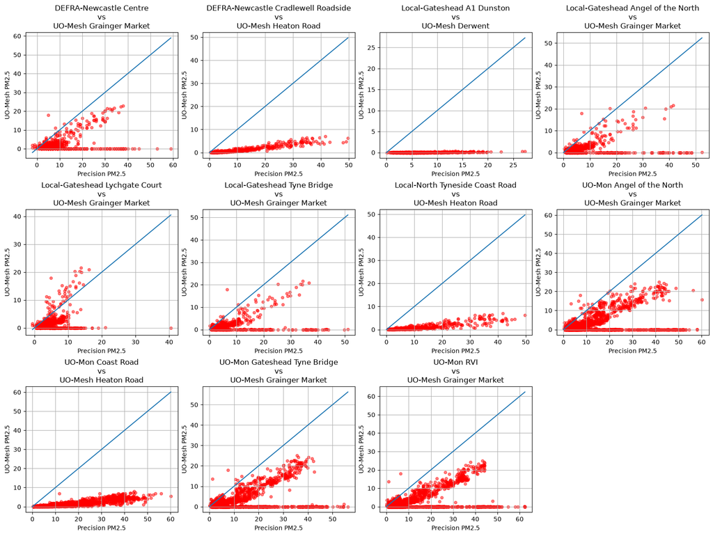

Figure 3 shows closest UO-Mon sensors to DEFRA/Local sensors, scatter plots and time series, where only the closest UO-Mon sensor is included for each DEFRA/Local sensor. This hopes to validate the UO-Mon sensor data and from both sets of plots we see very good agreement between the sensors. Figure 4 shows the same comparison as Figure 3 however the UO-Mon sensors under consideration (UO-Mon Gateshead Tyne Bridge and UO-Mon RVI) have already been compared to other DEFRA/Local sensors in Figure 3 that are much closer, we see worse agreement for two of the sensor comparisons here which is expected due to the distance. A summary table of correlational information and distances between sensors is given in Table 1 from which we see high correlation between all close sensors. We use both Pearson's and Spearman's correlation coefficents. Pearson's evaluates linear relationships and proportional change between variables while Spearman's monotonic relationships which dicerns if variables are changing together, not necessarily at a constant rate as Pearson's would let us assume. It is important to remember that other relationship (non-linear) might also exist as we see in the scaling differences between Loal A1 Dunston sensor and Local Gateshead Lychgate Court sensors with their closest UO-Mon sensor. This could be attributed to their further distance from thier closest UO-Mon if it were not for DEFRA Newcastle Cradlewell Roadside case which is further away from it's closest UO-Mon than the Local Gateshead Lychgate Court sensor. It could also be attributed to the fact that we are comparing the same monitor sensor for 4 of the DEFRA/Local sensors as there are no closer UO-Mon sensors in the area. Another issue is the case of DEFRA Newcastle Centre sensor, this is systematically rounding values to the closest integer, we will see this more clearly when analysing weekly data but here you can spot it in the time series plot.

Figure 3: Comparison of PM2.5 concentrations measured by each DEFRA/Local sensor and its closest UO-Mon sensor over the study period. Only the closest UO-Mon sensor is included for each DEFRA/Local sensor.

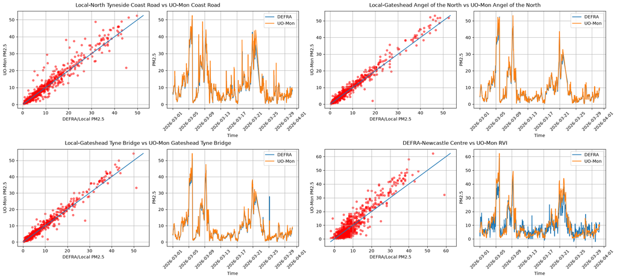

Figure 4: Comparison of PM2.5 concentrations measured by DEFRA/Local sensors and additional nearby UO-Mon sensors over the study period. These comparisons exclude the nearest UO-Mon sensor shown in Figure 3 and illustrate relationships with other matched UO-Mon sensors.

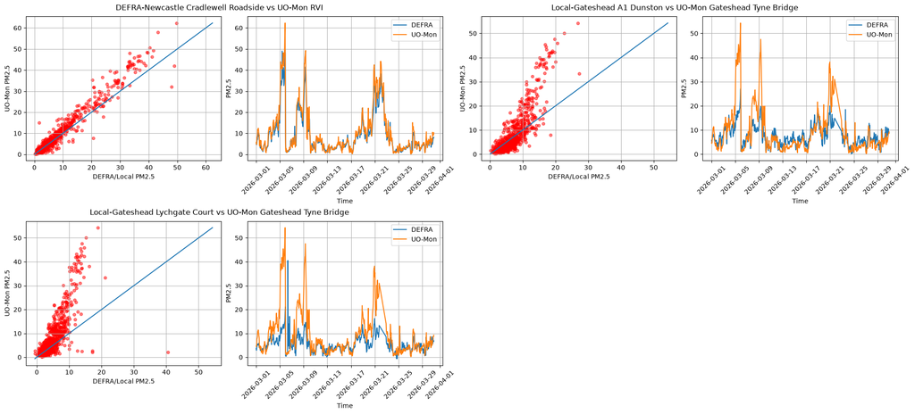

Table 1: Distances between sensors in km and , Pearson's and Spearman's correlations for UO-Mon and closest DEFRA/Local sensors PM2.5 concentrations over long time interval.

| DEFRA/Local | UO-Mon | Distance km | Bird Flight Distance | Pearsons corr | Spearmans corr |
| --- | --- | --- | --- | --- | --- |
| Local-Gateshead Angel of the North | UO-Mon Angel of the North | 0.003 | 0.000 | 0.986 | 0.962 |
| Local-Gateshead Tyne Bridge | UO-Mon Gateshead Tyne Bridge | 0.006 | 0.000 | 0.983 | 0.971 |
| DEFRA-Newcastle Cradlewell Roadside | UO-Mon RVI | 1.643 | 0.023 | 0.974 | 0.950 |
| Local-North Tyneside Coast Road | UO-Mon Coast Road | 0.002 | 0.000 | 0.961 | 0.954 |
| DEFRA-Newcastle Centre | UO-Mon RVI | 0.468 | 0.007 | 0.926 | 0.812 |
| Local-Gateshead A1 Dunston | UO-Mon Gateshead Tyne Bridge | 3.370 | 0.049 | 0.846 | 0.834 |
| Local-Gateshead Lychgate Court | UO-Mon Gateshead Tyne Bridge | 0.572 | 0.007 | 0.741 | 0.789 |

Figure 5: Correlation coefficents of each sensor pair from Figure 3 and Table 1 with their bird's flight distance.

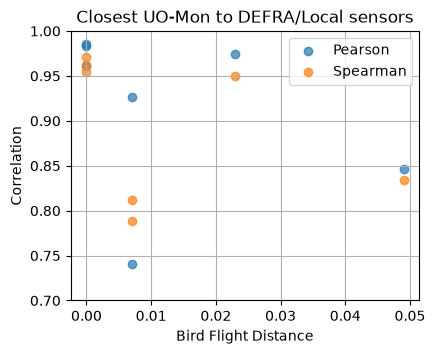

## 3. Weekly data

We took the last week (30th March-5th April) of March 2026 to look at correlation comparisons in PM2.5 concentrations between the UO-Mesh sensors to UO-Mon sensors. We also looked at correlational comparisons of PM2.5 and NOx/NO2 concentrations in the same sensors for all DEFRA, Local and UO-Mon sensors.

### 3.1 PM2.5 comparisons between close sensors

Figure 6: PM2.5 concentrations comparisons between UO-Mesh and closest UO-Mon sensors over short time interval.

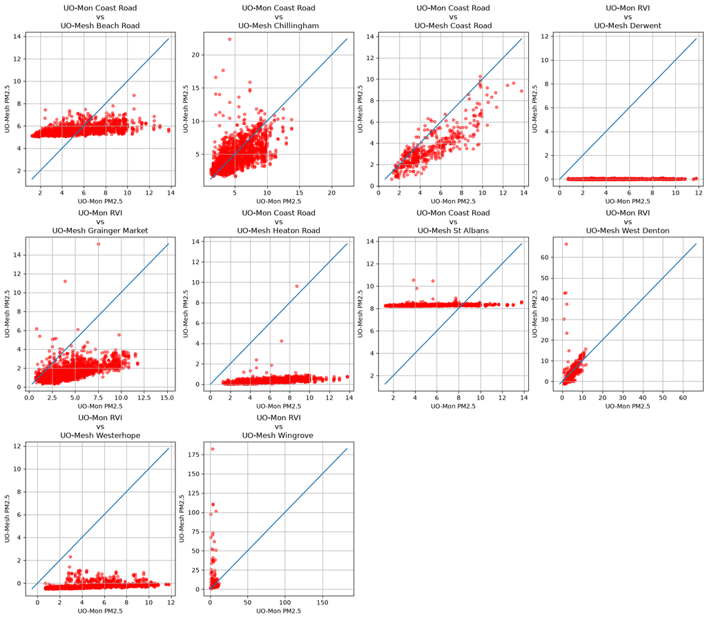

Table 2: Distances between sensors in km and bird flight, Pearson's and Spearman's correlations for UO-Mesh and closest UO-Mon sensors PM2.5 concentrations over short time interval.

| UO-Mesh | UO-Mon | Distance km | Bird Flight Distance | Pearsons corr | Spearmans corr |
| --- | --- | --- | --- | --- | --- |
| UO-Mesh Coast Road | UO-Mon Coast Road | 0.033 | 0.000 | 0.848 | 0.836 |
| UO-Mesh Chillingham | UO-Mon Coast Road | 1.757 | 0.021 | 0.544 | 0.615 |
| UO-Mesh Grainger Market | UO-Mon RVI | 0.754 | 0.007 | 0.538 | 0.640 |
| UO-Mesh Beach Road | UO-Mon Coast Road | 6.150 | 0.092 | 0.531 | 0.590 |
| UO-Mesh West Denton | UO-Mon RVI | 6.098 | 0.094 | 0.479 | 0.807 |
| UO-Mesh Heaton Road | UO-Mon Coast Road | 1.709 | 0.026 | 0.401 | 0.672 |
| UO-Mesh Westerhope | UO-Mon RVI | 6.045 | 0.089 | 0.385 | 0.691 |
| UO-Mesh St Albans | UO-Mon Coast Road | 1.904 | 0.018 | 0.231 | 0.499 |
| UO-Mesh Derwent | UO-Mon RVI | 5.252 | 0.076 | 0.151 | 0.165 |
| UO-Mesh Wingrove | UO-Mon RVI | 1.985 | 0.031 | -0.014 | 0.519 |

### 3.2 NOx and NO2 comparisons between same sensors

First NOx and NO2 concentration comparison in the DEFRA sensors to dicern if PM2.5 has any traffic dependency in the same way that NO2 and NOx have. In Figure 7 scatter plots, we see very clearly here the systematic categorisation of the DEFRA Newcastle Centre sensor. Low correlation values can be seen for all in Table 3.

Figure 7: Comparsion of PM2.5 and NOx and NO2 concentrations for DEFRA sensors over short time interval.

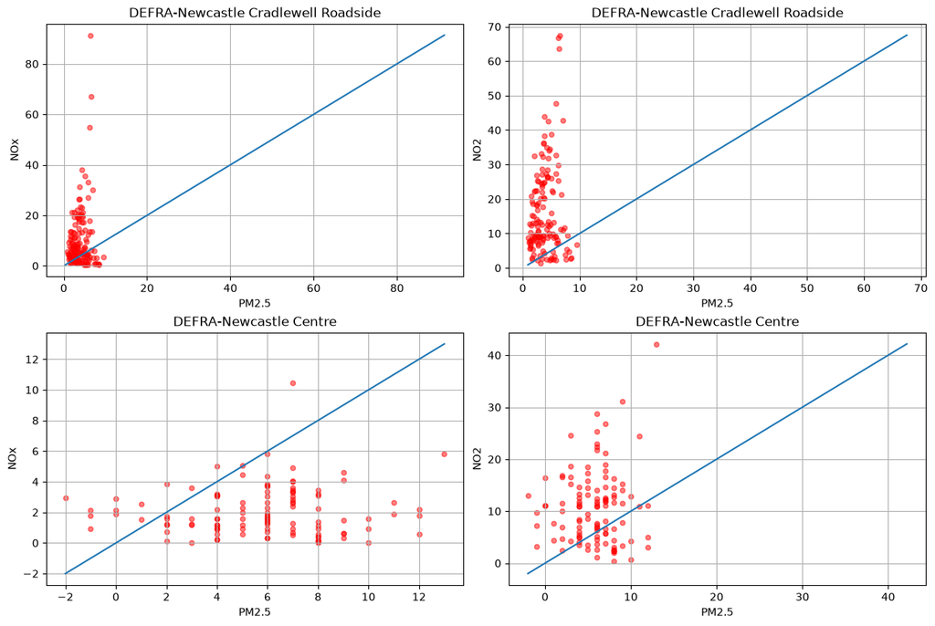

Table 3: Pearson's and Spearman's correlations for DEFRA sensor PM2.5 concentrations and NOx, NO2 concentrations over short time interval.

| DEFRA | Pearsons corr NOx | Spearmans corr NOx | Pearsons corr NO2 | Spearmans corr NO2 |
| --- | --- | --- | --- | --- |
| DEFRA-Newcastle Cradlewell Roadside | 0.152 | -0.014 | 0.142 | 0.100 |
| DEFRA-Newcastle Centre | 0.050 | -0.016 | 0.093 | -0.033 |

Figure 8: Comparisons of Local sensor PM2.5 and NO2 concentrations over short time interval.

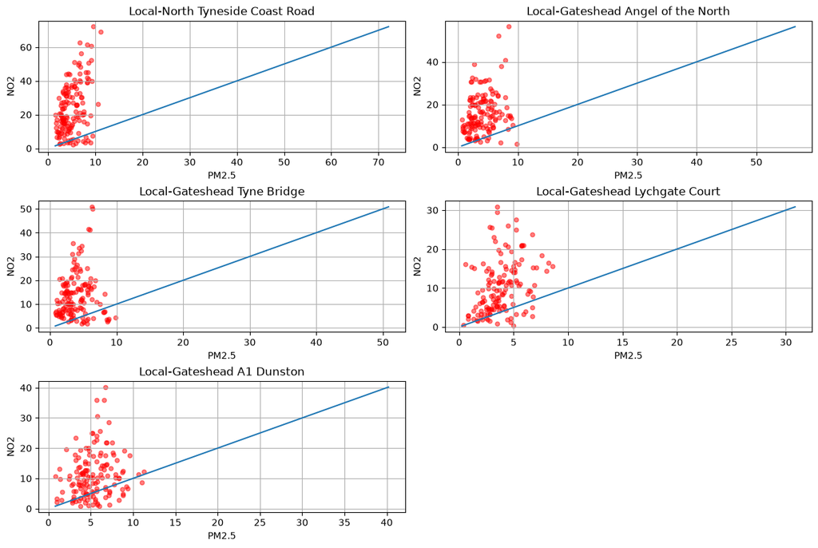

Table 4: Pearson's and Spearman's correlations for Local sensor PM2.5 concentrations and NO2 concentrations over short time interval.

| Local | Pearsons corr NO2 | Spearmans corr NO2 |
| --- | --- | --- |
| Local-North Tyneside Coast Road | 0.439 | 0.371 |
| Local-Gateshead Lychgate Court | 0.339 | 0.398 |
| Local-Gateshead Angel of the North | 0.254 | 0.287 |
| Local-Gateshead A1 Dunston | 0.167 | 0.186 |
| Local-Gateshead Tyne Bridge | 0.120 | 0.129 |

Figure 9: Comparisons of UO-Mon sensor PM2.5 and NOx concentrations over short time interval.

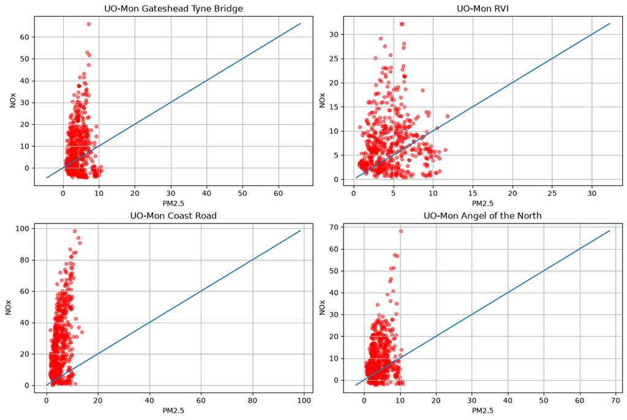

Table 5: Pearson's and Spearman's correlations for UO-Mon sensor PM2.5 concentrations and NOx concentrations over short time interval.

| UO-Mon | Pearsons corr NOx | Spearmans corr NOx |
| --- | --- | --- |
| UO-Mon Coast Road | 0.461 | 0.401 |
| UO-Mon Angel of the North | 0.231 | 0.199 |
| UO-Mon Gateshead Tyne Bridge | 0.107 | 0.118 |
| UO-Mon RVI | 0.079 | 0.134 |

## 4. Attributes affecting PM2.5 concentraions

### 4.1 Wind direction and speed

Wind data from UO-Mon sensors was taken for the month of March 2026, which turned out to be faulty as seen from Figure 10 below showing constant speed and direction over the course of the entire day/week/month. Further to this we analysed wind data from two older UO sensors in Birtley and West Denton to see if we could dicern anything interesting.

Figure 10: Wind speed and direction comparisons to PM2.5 concentrations from the UO-Mon sensors.

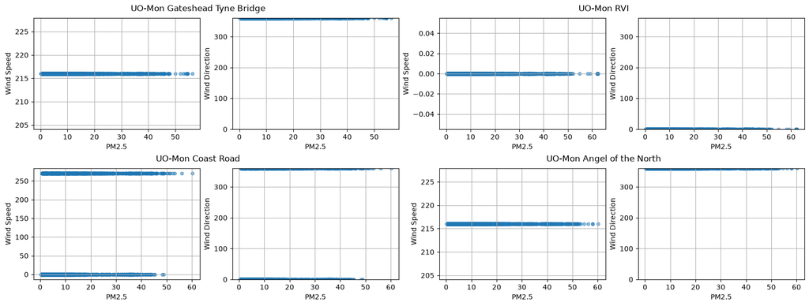

[figure not shown]

Figure 12: Scatter plots of PM2.5 concentration to wind speed coloured by wind direction, rose plots of PM2.5 concentration to wind direction, and binned plots of wind speed and direction coloured by PM2.5 concentration for the closest UO-Mon sensors to UO wind sensors in Birtley and West Denton

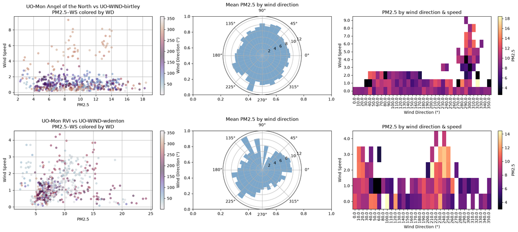

Figure 13: Scatter plots of PM2.5 concentration to wind speed coloured by wind direction, rose plots of PM2.5 concentration to wind direction, and binned plots of wind speed and direction coloured by PM2.5 concentration for the closest Local sensors to UO wind sensors in Birtley and West Denton

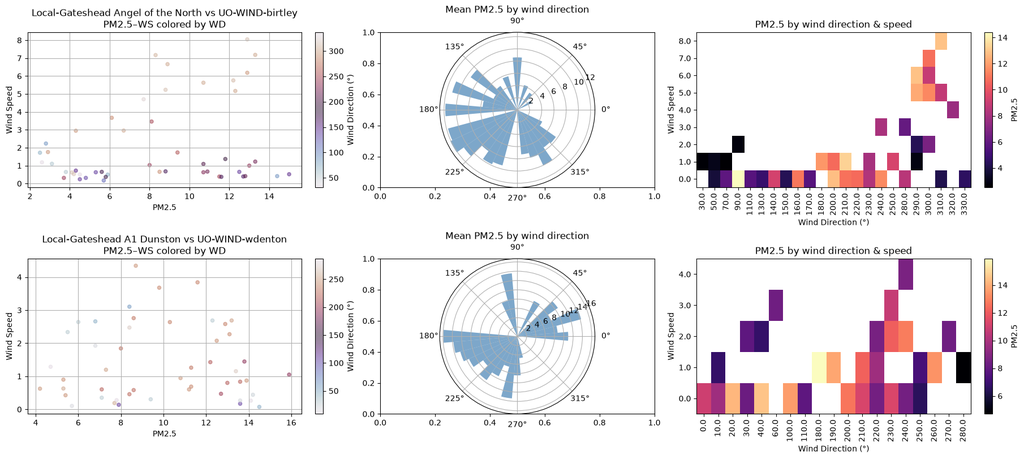

### 4.2 Altitude

We have used Newcastle upon Tyne extent of the DEFRA/Local/UO-Mon sensor area Ordinate Survey digital elevation map to evaluate whether any concentration level could be attributed to altitude of the sensors. From Figuare 14 where we look and mean and standard deviations for each sensor PM2.5 data over the course of the month with their altitude we see that there is a small positive correlation for mean and a moderate positive correlation for the standard deviation which indicates the higher altitude could affect higher variability in PM2.5 concentrations.

Figure 14: Altitude of DEFRA/Local/UO-Mon sensors with mean and standard deviation in PM2.5 concentration over long time interval

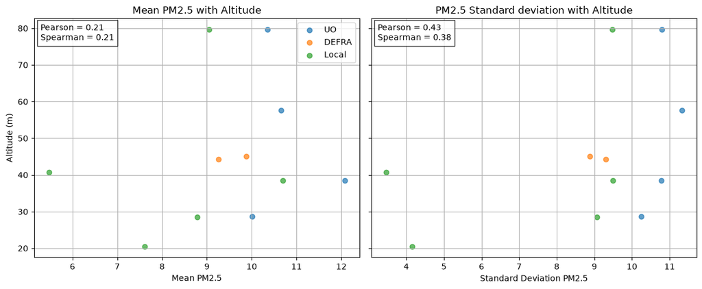

### 4.2 Temperature

We compared UO-Mon sensor PM2.5 with the same sensor temperature data over March 2026 in order to discern if there is relationship as our analysis with the NOx and NO2 concentrations could suggest that other factors may be of interest. In Figure 15, we can see scatter plots for temperature comparison with PM2.5 concentration for the UO-Mon sensors which, alongside low correlation values seen in Table 6, suggest very little relation between temperature and PM2.5 concentrations for at least a monthly time scale.

Figure 15: Comaprsion on PM2.5 concentration and temperature from UO-Mon sensors.

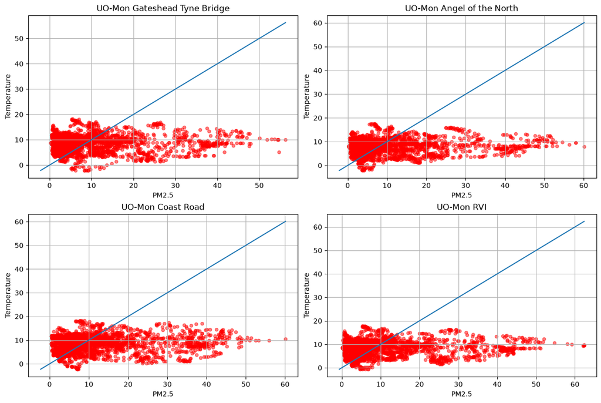

Table 6: Pearson's and Spearman's correlations for UO-Mon sensor PM2.5 concentrations and temperature over long time interval.

| UO-Mon | Pearsons corr Temp | Spearmans corr Temp |
| --- | --- | --- |
| UO-Mon Coast Road | 0.140 | 0.177 |
| UO-Mon Angel of the North | 0.114 | 0.082 |
| UO-Mon RVI | 0.086 | 0.073 |
| UO-Mon Gateshead Tyne Bridge | 0.061 | 0.039 |